# DA 460 - Lab 1

Marjorie Blanco

July 08, 2018

# Handout 1 R: Introduction to data

Data Source: US CDC website.

- genhlth: A categorical vector indicating general health, with categories excellent, very good, good, fair, and poor.
- exerany: A categorical vector, 1 if the respondent exercised in the past month and 0 otherwise.
- hlthplan: A categorical vector, 1 if the respondent has some form of health coverage and 0 otherwise.
- smoke100: A categorical vector, 1 if the respondent has smoked at least 100 cigarettes in their entire life and 0 otherwise.
- height: A numerical vector, respondent’s height in inches.
- weight: A numerical vector, respondent’s weight in pounds.
- wtdesire: A numerical vector, respondent’s desired weight in pounds.
- age: A numerical vector, respondent’s age in years.
- gender: A categorical vector, respondent’s gender.

## Getting started

```r
# Load BRFSS data
source("http://www.openintro.org/stat/data/cdc.R")

# view the names of the variables
names(cdc)
```

```
## [1] "genhlth"  "exerany"  "hlthplan" "smoke100" "height"   "weight"
## [7] "wtdesire" "age"      "gender"
```

### Exercise 1

How many cases are there in this data set? How many variables? For each variable, identify its data type (e.g. categorical, discrete).

he dimensions of the data frame is 20000, 9. There are 20000 records and 9 variables in this data set. The variable names are: genhlth, exerany, hlthplan, smoke100, height, weight, wtdesire, age, gender.

Four variables are discrete (height, weight, wtdesire and age) and the remaining five are categorical. One categorical variable, genhlth, is ordinal.

- genhlth: categorical (ordinal)
- exerany: categorical
- hlthplan: categorical
- smoke100: categorical
- height: numerical
- weight: numerical
- wtdesire: numerical
- age: numerical
- gender: categorical

```r
# Look at the first few entries (rows) for our data set
head(cdc)
```

```
##     genhlth exerany hlthplan smoke100 height weight wtdesire age gender
## 1      good       0        1        0     70    175      175  77      m
## 2      good       0        1        1     64    125      115  33      f
## 3      good       1        1        1     60    105      105  49      f
## 4      good       1        1        0     66    132      124  42      f
## 5 very good       0        1        0     61    150      130  55      f
## 6 very good       1        1        0     64    114      114  55      f
```

```r
# Look at the last few entries (rows) for our data set
tail(cdc)
```

```
##         genhlth exerany hlthplan smoke100 height weight wtdesire age
## 19995      good       0        1        1     69    224      224  73
## 19996      good       1        1        0     66    215      140  23
## 19997 excellent       0        1        0     73    200      185  35
## 19998      poor       0        1        0     65    216      150  57
## 19999      good       1        1        0     67    165      165  81
## 20000      good       1        1        1     69    170      165  83
##       gender
## 19995      m
## 19996      f
## 19997      m
## 19998      f
## 19999      f
## 20000      m
```

## Summaries and tables

```r
# summary statistics for weight
summary(cdc$weight)
```

```
##    Min. 1st Qu.  Median    Mean 3rd Qu.    Max.
##    68.0   140.0   165.0   169.7   190.0   500.0
```

```r
# mean (average) for weight
mean(cdc$weight)
```

```
## [1] 169.683
```

```r
# variance for weight
var(cdc$weight)
```

```
## [1] 1606.484
```

```r
# median for weight
median(cdc$weight)
```

```
## [1] 165
```

```r
# compute the interquartile range for the respondents’ weight
190 - 140
```

```
## [1] 50
```

```r
# sample frequency for smoke100
table(cdc$smoke100)
```

```
##
##     0     1
## 10559  9441
```

```r
# relative frequency distribution for smoke100
table(cdc$smoke100)/20000
```

```
##
##       0       1
## 0.52795 0.47205
```

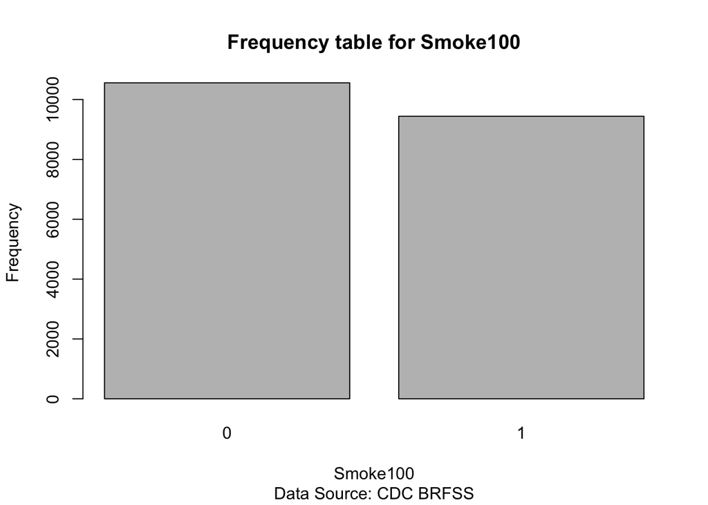

```r
# barplot
barplot(table(cdc$smoke100), main = "Frequency table for Smoke100",
       xlab = "Smoke100", ylab = "Frequency", sub="Data Source: CDC BRFSS")

# object, a table, called smoke
smoke <- table(cdc$smoke100)
# make a bar plot of the entries
barplot(smoke, main = "Frequency table for Smoke100",
       xlab = "Smoke100", ylab = "Frequency", sub="Data Source: CDC BRFSS")
```